# Открытие депозита

```r
# Multiple plot function
#
# ggplot objects can be passed in ..., or to plotlist (as a list of ggplot objects)
# - cols:   Number of columns in layout
# - layout: A matrix specifying the layout. If present, 'cols' is ignored.
#
# If the layout is something like matrix(c(1,2,3,3), nrow=2, byrow=TRUE),
# then plot 1 will go in the upper left, 2 will go in the upper right, and
# 3 will go all the way across the bottom.
#
multiplot <- function(..., plotlist=NULL, file, cols=1, layout=NULL) {
  library(grid)

  # Make a list from the ... arguments and plotlist
  plots <- c(list(...), plotlist)

  numPlots = length(plots)

  # If layout is NULL, then use 'cols' to determine layout
  if (is.null(layout)) {
    # Make the panel
    # ncol: Number of columns of plots
    # nrow: Number of rows needed, calculated from # of cols
    layout <- matrix(seq(1, cols * ceiling(numPlots/cols)),
                    ncol = cols, nrow = ceiling(numPlots/cols))
  }

 if (numPlots==1) {
    print(plots[[1]])

  } else {
    # Set up the page
    grid.newpage()
    pushViewport(viewport(layout = grid.layout(nrow(layout), ncol(layout))))

    # Make each plot, in the correct location
    for (i in 1:numPlots) {
      # Get the i,j matrix positions of the regions that contain this subplot
      matchidx <- as.data.frame(which(layout == i, arr.ind = TRUE))

      print(plots[[i]], vp = viewport(layout.pos.row = matchidx$row,
                                      layout.pos.col = matchidx$col))
    }
  }
}
```

## ДЗ 3

Имеются результаты обзвона 4119 клиентов португальского банка, которым предлагалось завести депозит. Известны социально-демографические характеристики клиентов, история предыдущих коммуникаций, социально-экономические показатели на момент совершения звонка. (deposit.xlsx)

**Задание**: Какие признаки определяют готовность клиента открыть депозит по результатам обзвона?

- визуализация данных, анализ распределения признаков (оценка необходимости трансформации), оценка наличия выбросов;
- оценка необходимости преобразования отклика и его поиск методом Бокса-Кокса; визуальный анализ остатков;
- проверка гипотез об остатках: нормальность, несмещённость, гомоскедастичность;
- отбор признаков с учётом множественной проверки гипотез и возможной гетероскедастичности;
- анализ необходимости добавления взаимодействий и квадратов признаков;
- расчёт расстояний Кука, возможное удаление выбросов, обновление модели;
- визуализация данных, оценка наличия выбросов, анализ таблиц сопряжённости по категориальным признакам;
- содержательный отбор признаков: выбор наилучшей линейной модели, оценка линейности непрерывных признаков по логиту, анализ необходимости добавления взаимодействий, проверка адекватности финальной модели (анализ влиятельных наблюдений, классификация);
- выводы.

Input variables: # bank client data: 1 - age (numeric) 2 - job : type of job (categorical: “admin.”, “blue-collar”, “entrepreneur”, “housemaid”, “management”, “retired”, “self-employed”, “services”, “student”, “technician”, “unemployed”, “unknown”) 3 - marital : marital status (categorical: “divorced”, “married”, “single”, “unknown”; note: “divorced” means divorced or widowed) 4 - education (categorical: “basic.4y”, “basic.6y”, “basic.9y”, “high.school”, “illiterate”, “professional.course”, “university.degree”, “unknown”) 5 - default: has credit in default? (categorical: “no”,“yes”,“unknown”) 6 - housing: has housing loan? (categorical: “no”,“yes”,“unknown”) 7 - loan: has personal loan? (categorical: “no”,“yes”,“unknown”)

# related with the last contact of the current campaign: 8 - contact: contact communication type (categorical: “cellular”,“telephone”) 9 - month: last contact month of year (categorical: “jan”, “feb”, “mar”, …, “nov”, “dec”) 10 - day_of_week: last contact day of the week (categorical: “mon”,“tue”,“wed”,“thu”,“fri”) 11 - duration: last contact duration, in seconds (numeric). Important note: this attribute highly affects the output target (e.g., if duration=0 then y=“no”). Yet, the duration is not known before a call is performed. Also, after the end of the call y is obviously known. Thus, this input should only be included for benchmark purposes and should be discarded if the intention is to have a realistic predictive model. # other attributes: 12 - campaign: number of contacts performed during this campaign and for this client (numeric, includes last contact) 13 - pdays: number of days that passed by after the client was last contacted from a previous campaign (numeric; 999 means client was not previously contacted) 14 - previous: number of contacts performed before this campaign and for this client (numeric) 15 - poutcome: outcome of the previous marketing campaign (categorical: “failure”,“nonexistent”,“success”)

# social and economic context attributes 16 - emp.var.rate: employment variation rate - quarterly indicator (numeric) 17 - cons.price.idx: consumer price index - monthly indicator (numeric)  
18 - cons.conf.idx: consumer confidence index - monthly indicator (numeric)  
19 - euribor3m: euribor 3 month rate - daily indicator (numeric) 20 - nr.employed: number of employees - quarterly indicator (numeric)

Output variable (desired target): 21 - y - has the client subscribed a term deposit? (binary: “yes”,“no”)

```r
factor_cols <- c("y", "job", "marital", "education", "default", "housing", "loan", "day_of_week", "month", "contact", "poutcome")

numeric_cols <- c("age", "campaign", "duration", "pdays", "previous", "emp.var.rate", "cons.price.idx", "cons.conf.idx", "euribor3m", "nr.employed")

data <- read.csv("./deposit.csv", header = TRUE, sep = ";")

for (col in factor_cols) {
  data[[col]] <- as.factor(data[[col]])
}

for (col in numeric_cols) {
  data[[col]] <- as.numeric(data[[col]])
}

raw_data <- data
colnames(data)
```

```
##  [1] "age"            "job"            "marital"        "education"
##  [5] "default"        "housing"        "loan"           "contact"
##  [9] "month"          "day_of_week"    "duration"       "campaign"
## [13] "pdays"          "previous"       "poutcome"       "emp.var.rate"
## [17] "cons.price.idx" "cons.conf.idx"  "euribor3m"      "nr.employed"
## [21] "y"
```

# Data preparation

## Categorical

```r
cols_with_unknow <- c("job", "marital", "education", "default", "housing", "loan")
for (col in cols_with_unknow) {
  levels(data[[col]])[levels(data[[col]])=="unknown"] <- NA
  data[[col]] <- droplevels(data[[col]])
}

na_data <- data[!complete.cases(data),]
print(c(nrow(na_data), nrow(data)))
```

```
## [1] 1029 4119
```

```r
Filter(function(x) { x > 0}, sapply(na_data, function(x) {sum(is.na(x))}))
```

```
##       job   marital education   default   housing      loan
##        39        11       167       803       105       105
```

```r
ftable(data$default, data$y, exclude = c())
```

```
##        no  yes   NA
##
## no   2913  402    0
## yes     1    0    0
## NA    754   49    0
```

Признак default неинформативен: 1 из 3316 записей имеет кредит по умолчанию, по 803 информация неизвестна, удалим его.

```r
data$default <- NULL
ftable(data$job, data$y, exclude = c())
```

```
##                 no yes  NA
##
## admin.         879 133   0
## blue-collar    823  61   0
## entrepreneur   140   8   0
## housemaid       99  11   0
## management     294  30   0
## retired        128  38   0
## self-employed  146  13   0
## services       358  35   0
## student         63  19   0
## technician     611  80   0
## unemployed      92  19   0
## NA              35   4   0
```

```r
ftable(data$marital, data$y, exclude = c())
```

```
##             no  yes   NA
##
## divorced   403   43    0
## married   2257  252    0
## single     998  155    0
## NA          10    1    0
```

```r
ftable(data$education, data$y, exclude = c())
```

```
##                        no  yes   NA
##
## basic.4y              391   38    0
## basic.6y              211   17    0
## basic.9y              531   43    0
## high.school           824   97    0
## illiterate              1    0    0
## professional.course   470   65    0
## university.degree    1099  165    0
## NA                    141   26    0
```

```r
ftable(data$housing, data$y, exclude = c())
```

```
##        no  yes   NA
##
## no   1637  202    0
## yes  1935  240    0
## NA     96    9    0
```

```r
ftable(data$loan, data$y, exclude = c())
```

```
##        no  yes   NA
##
## no   2975  374    0
## yes   597   68    0
## NA     96    9    0
```

```r
all((raw_data$housing == "unknown") == (raw_data$loan == "unknown"))
```

```
## [1] TRUE
```

```r
sum(raw_data$loan == "unknown")
```

```
## [1] 105
```

По illiterate признака education только одна запись, удалим ее. (1 запись) По признакам housing и loan значение unknown совпадает у всех записей.

```r
data <- data[(data$education != "illiterate" | is.na(data$education)),]
data$education <- droplevels(data$education)

data <- data[(!is.na(data$loan)),]
data$housing <- droplevels(data$housing)
data$loan <- droplevels(data$loan)

ftable(data$job, data$y, exclude = c())
```

```
##                 no yes  NA
##
## admin.         865 132   0
## blue-collar    796  60   0
## entrepreneur   138   8   0
## housemaid       96  11   0
## management     292  29   0
## retired        124  37   0
## self-employed  139  13   0
## services       340  34   0
## student         63  19   0
## technician     597  76   0
## unemployed      86  19   0
## NA              35   4   0
```

```r
# Осталось разобраться с job 35, 4
# Осталось разобраться с marital 10, 1
# Осталось разобраться с job 140, 26
```

```r
na_data <- data[!complete.cases(data),]
ftable(na_data$y, exclude = c())
```

```
##   no yes  NA
##
##  174  29   0
```

Удалим строки, содержащие пропуски (complete cases).

```r
data <- data[complete.cases(data),]
nrow(raw_data) - nrow(data)
```

```
## [1] 309
```

```r
nrow(data)
```

```
## [1] 3810
```

```r
ftable(data$y)
```

```
##    no  yes
##
##  3397  413
```

В итоге удалено 309 строк. Осталось 3810

job, marital, education, default, housing, loan

```r
library("ggplot2")
names(data)
```

```
##  [1] "age"            "job"            "marital"        "education"
##  [5] "housing"        "loan"           "contact"        "month"
##  [9] "day_of_week"    "duration"       "campaign"       "pdays"
## [13] "previous"       "poutcome"       "emp.var.rate"   "cons.price.idx"
## [17] "cons.conf.idx"  "euribor3m"      "nr.employed"    "y"
```

```r
ftable(data$y, data$contact)
```

```
##      cellular telephone
##
## no       2123      1274
## yes       346        67
```

```r
ftable(data$y, data$month)
```

```
##       apr  aug  dec  jul  jun  mar  may  nov  oct  sep
##
## no    165  532   10  599  424   19 1191  383   39   35
## yes    31   58    9   56   61   24   84   43   25   22
```

```r
ftable(data$y, data$day_of_week)
```

```
##      fri mon thu tue wed
##
## no   632 709 708 684 664
## yes   78  92  86  82  75
```

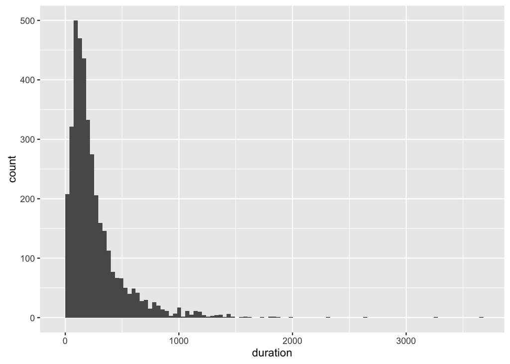

```r
ggplot(data, aes(duration)) + geom_histogram(bins = 100)
```

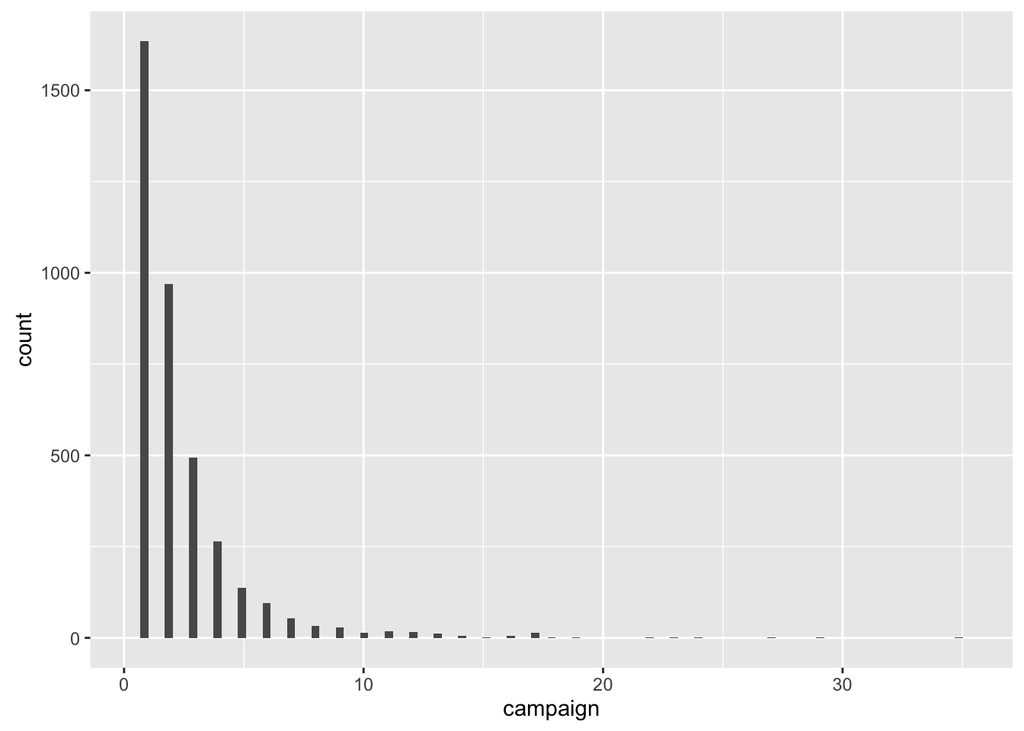

```r
ggplot(data, aes(campaign)) + geom_histogram(bins = 100)
```

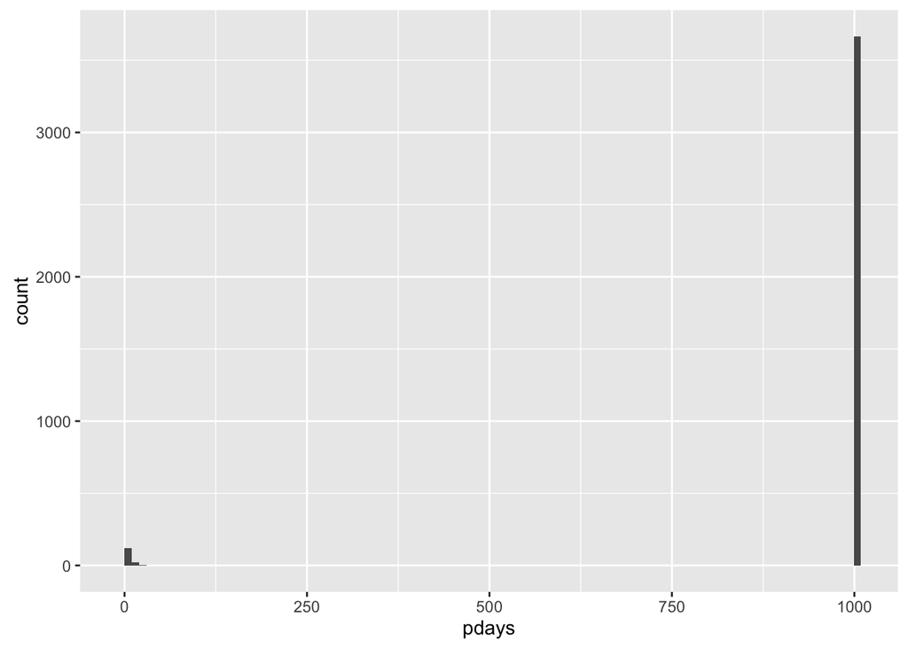

```r
ggplot(data, aes(pdays)) + geom_histogram(bins = 100)
```

```r
# pdays: number of days that passed by after the client was last
# contacted from a previous campaign
# (numeric; 999 means client was not previously contacted)
ftable(data$y, data$pdays) # to binary, 0 - wasn't , 1 - was.
```

```
##         0    1    2    3    4    5    6    7    9   10   11   12   13   14   15   16   18   19   21  999
##
## no      0    3    3   11    9    0   15    1    2    2    1    2    2    1    1    1    1    0    0 3342
## yes     2    0    1   36    4    4   25    5    0    6    0    3    0    0    1    0    0    1    1  324
```

```r
# previous: number of contacts performed before
# this campaign and for this client (numeric)
ftable(data$y, data$previous)
```

```
##         0    1    2    3    4    5    6
##
## no   2997  347   41    8    3    0    1
## yes   270   90   30   13    8    2    0
```

```r
# poutcome: outcome of the previous marketing campaign
# (categorical: "failure","nonexistent","success")
ftable(data$y, data$poutcome)
```

```
##      failure nonexistent success
##
## no       354        2997      46
## yes       60         270      83
```

```r
ftable(data$y, data$campaign)
```

```
##         1    2    3    4    5    6    7    8    9   10   11   12   13   14   15   16   17   18   19   22   23   24   27   29   35
##
## no   1437  857  440  234  129   91   53   31   28   14   18   16   11    5    2    6   13    1    2    2    2    1    1    2    1
## yes   198  113   53   30    9    4    1    2    1    1    1    0    0    0    0    0    0    0    0    0    0    0    0    0    0
```

Превратим pdays в бинарный признак, 0 - последний контакт был совершен в течении последнего месяца.

```r
data$was_contacted <- data$pdays != 999
ftable(data$y, data$was_contacted)
```

```
##      FALSE TRUE
##
## no    3342   55
## yes    324   89
```

```r
data$pdays <- NULL
```

## Numeric

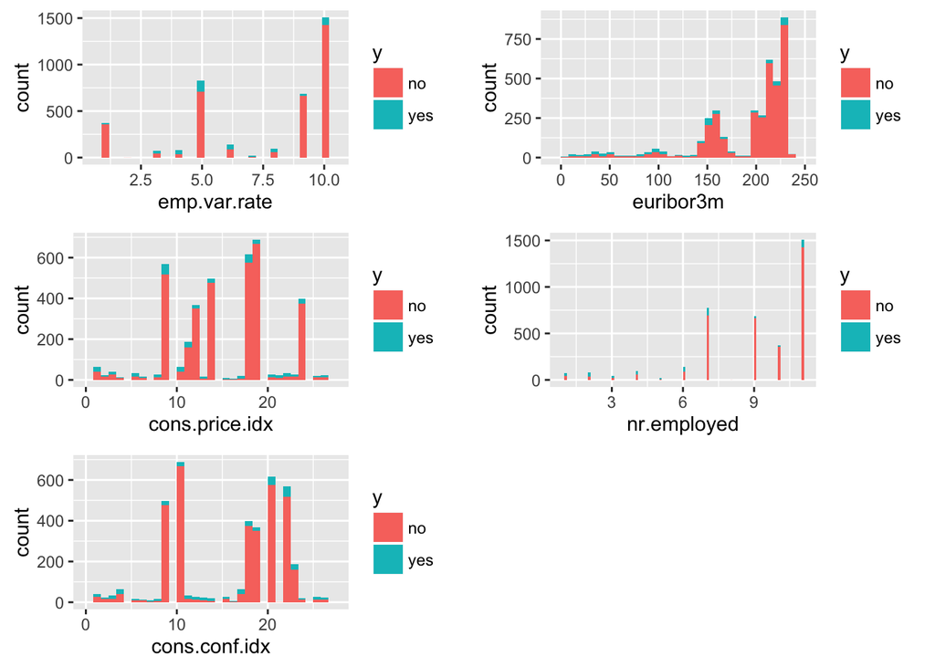

```r
p10 <- ggplot(data, aes(emp.var.rate, y)) + geom_point()
p11 <- ggplot(data, aes(emp.var.rate, fill = y)) + geom_histogram()

p20 <- ggplot(data, aes(cons.price.idx, y)) + geom_point()
p21 <- ggplot(data, aes(cons.price.idx, fill = y)) + geom_histogram()

p30 <- ggplot(data, aes(cons.conf.idx, y)) + geom_point()
p31 <- ggplot(data, aes(cons.conf.idx, fill = y)) + geom_histogram()

p40 <- ggplot(data, aes(euribor3m, y)) + geom_point()
p41 <- ggplot(data, aes(euribor3m, fill = y)) + geom_histogram()

p50 <- ggplot(data, aes(nr.employed, y)) + geom_point()
p51 <- ggplot(data, aes(nr.employed, fill = y)) + geom_histogram(bins = 100)

p60 <- ggplot(data, aes(age, y)) + geom_point()
p61 <- ggplot(data, aes(age, fill = y)) + geom_histogram(bins = 100)

p70 <- ggplot(data, aes(campaign, y)) + geom_point()
p71 <- ggplot(data, aes(campaign, fill = y)) + geom_histogram(bins = 100)

p80 <- ggplot(data, aes(duration, y)) + geom_point()
p81 <- ggplot(data, aes(duration, fill = y)) + geom_histogram(bins = 100)

p90 <- ggplot(data, aes(previous, y)) + geom_point()
p91 <- ggplot(data, aes(previous, fill = y)) + geom_histogram(bins = 100)

multiplot(p11, p21, p31, p41, p51, cols = 2)
```

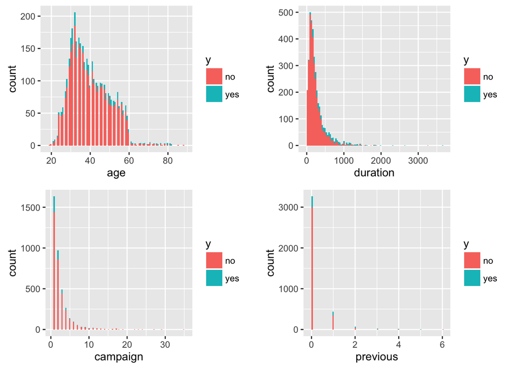

```r
multiplot(p61, p71, p81, p91, cols = 2)
```

Ничего хорошо по Numeric признакам не видно.

# Построение моделей

Для предварительного отбора признаков построим одномерные модели по каждому фактору и оценим их значимость:

```r
m0 <- glm(y ~ 1, family=binomial(), data=data)
add1(m0, scope = as.formula(paste("~", paste(setdiff(names(data), c("y")), collapse= " + "))), test="LRT")
```

```
## Single term additions
##
## Model:
## y ~ 1
##                Df Deviance    AIC    LRT  Pr(>Chi)
## <none>              2614.8 2616.8
## age             1   2606.7 2610.7   8.17 0.0042488 **
## job            10   2557.8 2579.8  57.04 1.313e-08 ***
## marital         2   2606.1 2612.1   8.74 0.0126267 *
## education       5   2597.2 2609.2  17.65 0.0034242 **
## housing         1   2614.8 2618.8   0.00 0.9497297
## loan            1   2614.4 2618.4   0.44 0.5050151
## contact         1   2533.1 2537.1  81.77 < 2.2e-16 ***
## month           9   2444.8 2464.8 170.09 < 2.2e-16 ***
## day_of_week     4   2614.1 2624.1   0.74 0.9460407
## duration        1   2122.8 2126.8 492.07 < 2.2e-16 ***
## campaign        1   2587.1 2591.1  27.73 1.392e-07 ***
## previous        1   2453.9 2457.9 160.96 < 2.2e-16 ***
## poutcome        2   2374.1 2380.1 240.76 < 2.2e-16 ***
## emp.var.rate    1   2552.1 2556.1  62.75 2.350e-15 ***
## cons.price.idx  1   2574.0 2578.0  40.80 1.684e-10 ***
## cons.conf.idx   1   2599.9 2603.9  14.93 0.0001116 ***
## euribor3m       1   2233.2 2237.2 381.59 < 2.2e-16 ***
## nr.employed     1   2244.2 2248.2 370.60 < 2.2e-16 ***
## was_contacted   1   2382.1 2386.1 232.71 < 2.2e-16 ***
## ---
## Signif. codes:  0 '***' 0.001 '**' 0.01 '*' 0.05 '.' 0.1 ' ' 1
```

В порог 0.25 по значимости не прошли housing, loan, day_of_week.

Закодируем категориальные признаки

```r
factor_cols
```

```
##  [1] "y"           "job"         "marital"     "education"   "default"
##  [6] "housing"     "loan"        "day_of_week" "month"       "contact"
## [11] "poutcome"
```

```r
data$marital <- relevel(data$marital, "married")
data$poutcome <- relevel(data$poutcome, "nonexistent")
length(levels(data$job))
```

```
## [1] 11
```

```r
contrasts(data$job) = contr.sum(length(levels(data$job)))
contrasts(data$education) = contr.sum(length(levels(data$education)))
contrasts(data$day_of_week) = contr.sum(length(levels(data$day_of_week)))
contrasts(data$month) = contr.sum(length(levels(data$month)))

levels(data$month)
```

```
##  [1] "apr" "aug" "dec" "jul" "jun" "mar" "may" "nov" "oct" "sep"
```

Построим по оставшимся модель 1

## Модель 1

```r
m0_eliminated <- c("y", "housing", "loan", "day_of_week")
paste(setdiff(names(data), m0_eliminated), collapse = ' + ')
```

```
## [1] "age + job + marital + education + contact + month + duration + campaign + previous + poutcome + emp.var.rate + cons.price.idx + cons.conf.idx + euribor3m + nr.employed + was_contacted"
```

```r
m1 <- glm(y ~ age + job + marital + education + contact + month + duration + campaign + previous + poutcome + emp.var.rate + cons.price.idx + cons.conf.idx + euribor3m + nr.employed + was_contacted, family=binomial(), data=data)
summary(m1)
```

```
##
## Call:
## glm(formula = y ~ age + job + marital + education + contact +
##     month + duration + campaign + previous + poutcome + emp.var.rate +
##     cons.price.idx + cons.conf.idx + euribor3m + nr.employed +
##     was_contacted, family = binomial(), data = data)
##
## Deviance Residuals:
##     Min       1Q   Median       3Q      Max
## -4.7686  -0.2905  -0.1788  -0.1165   3.1236
##
## Coefficients:
##                     Estimate Std. Error z value Pr(>|z|)
## (Intercept)       -0.2456234  0.6105263  -0.402 0.687453
## age                0.0045979  0.0084537   0.544 0.586517
## job1               0.0223048  0.1695084   0.132 0.895312
## job2              -0.0110787  0.2215589  -0.050 0.960120
## job3              -0.8344333  0.4773693  -1.748 0.080467 .
## job4               0.3953645  0.3972866   0.995 0.319658
## job5              -0.2531684  0.2656350  -0.953 0.340555
## job6              -0.1485499  0.3094077  -0.480 0.631149
## job7              -0.5263379  0.3840215  -1.371 0.170501
## job8               0.2271764  0.2557461   0.888 0.374385
## job9               0.3229958  0.3887164   0.831 0.406014
## job10              0.2643817  0.1981356   1.334 0.182090
## maritaldivorced   -0.1523248  0.2481794  -0.614 0.539368
## maritalsingle      0.0404598  0.1797499   0.225 0.821910
## education1        -0.1294238  0.2271866  -0.570 0.568894
## education2         0.1624197  0.2917108   0.557 0.577675
## education3        -0.0774529  0.2019277  -0.384 0.701299
## education4        -0.0211954  0.1644990  -0.129 0.897478
## education5        -0.0962119  0.2007773  -0.479 0.631798
## contacttelephone  -0.7668285  0.2711468  -2.828 0.004683 **
## month1            -0.2825966  0.2748977  -1.028 0.303947
## month2            -0.0261315  0.2589305  -0.101 0.919613
## month3            -0.2077497  0.5657450  -0.367 0.713459
## month4            -0.0360893  0.2501400  -0.144 0.885282
## month5             0.9598547  0.2317279   4.142 3.44e-05 ***
## month6             1.5823569  0.3768891   4.198 2.69e-05 ***
## month7            -0.7726177  0.1858863  -4.156 3.23e-05 ***
```

[output cut: 8 more lines]

```
## cons.price.idx    -0.0288666  0.0171245  -1.686 0.091856 .
## cons.conf.idx     -0.0058600  0.0242343  -0.242 0.808929
## euribor3m         -0.0059917  0.0038820  -1.543 0.122718
## nr.employed       -0.2659626  0.0744922  -3.570 0.000357 ***
## was_contactedTRUE  0.3201998  0.6777198   0.472 0.636594
## ---
## Signif. codes:  0 '***' 0.001 '**' 0.01 '*' 0.05 '.' 0.1 ' ' 1
##
## (Dispersion parameter for binomial family taken to be 1)
##
##     Null deviance: 2614.8  on 3809  degrees of freedom
## Residual deviance: 1479.8  on 3770  degrees of freedom
## AIC: 1559.8
##
## Number of Fisher Scoring iterations: 7
```

Категориальный предиктор, кодируемый несколькими фиктивными переменными, необходимо включать или исключать целиком. Значимость соответствующих фиктивных переменных проверяется в совокупности с помощью критерия отношения правдоподобия. В случае, когда по отдельности какие-то фиктивные переменные не значимы, допустимо объединять уровни категориального предиктора, основываясь на интерпретации.

Незначимые признаки age, job, marital, education, previous, emp.var.rate, cons.conf.idx, euribor3m, was_contacted

Раздел их на две группы:

- job, education, previous, was_contacted
- age, marital, emp.var.rate, cons.conf.idx, euribor3m

```r
m1_eliminated <- c("age", "job", "marital", "education", "previous", "emp.var.rate", "cons.conf.idx", "euribor3m", "was_contacted")
m1_eliminated_g0 <- c("job", "education", "previous", "was_contacted")
m1_eliminated_g1 <- c("age", "marital", "emp.var.rate", "cons.conf.idx", "euribor3m")
```

Критерий отношения правдоподобия считает такую модель существенно лучшей константы:

```r
library(lmtest)
lrtest(m0, m1)
```

```
## Likelihood ratio test
##
## Model 1: y ~ 1
## Model 2: y ~ age + job + marital + education + contact + month + duration +
##     campaign + previous + poutcome + emp.var.rate + cons.price.idx +
##     cons.conf.idx + euribor3m + nr.employed + was_contacted
##   #Df   LogLik Df  Chisq Pr(>Chisq)
## 1   1 -1307.42
## 2  40  -739.89 39 1135.1  < 2.2e-16 ***
## ---
## Signif. codes:  0 '***' 0.001 '**' 0.01 '*' 0.05 '.' 0.1 ' ' 1
```

## Модель 2

Новая модель без незначимых признаков:

```r
paste(setdiff(names(data), c(m0_eliminated, m1_eliminated)), collapse = ' + ')
```

```
## [1] "contact + month + duration + campaign + poutcome + cons.price.idx + nr.employed"
```

```r
m2 <- glm(y ~ contact + month + duration + campaign + poutcome + cons.price.idx + nr.employed,
          family=binomial(),
          data=data)
summary(m2)
```

```
##
## Call:
## glm(formula = y ~ contact + month + duration + campaign + poutcome +
##     cons.price.idx + nr.employed, family = binomial(), data = data)
##
## Deviance Residuals:
##     Min       1Q   Median       3Q      Max
## -4.8709  -0.2896  -0.1778  -0.1238   3.0308
##
## Coefficients:
##                    Estimate Std. Error z value Pr(>|z|)
## (Intercept)       0.1685176  0.2890977   0.583 0.559955
## contacttelephone -0.5534963  0.2183598  -2.535 0.011251 *
## month1           -0.4790925  0.2387419  -2.007 0.044778 *
## month2            0.0586459  0.1924824   0.305 0.760609
## month3            0.2080348  0.5248276   0.396 0.691820
## month4            0.0492989  0.2290870   0.215 0.829613
## month5            0.9575929  0.2097221   4.566 4.97e-06 ***
## month6            1.4796192  0.3367816   4.393 1.12e-05 ***
## month7           -0.9513260  0.1596013  -5.961 2.51e-09 ***
## month8           -0.7021837  0.2233419  -3.144 0.001667 **
## month9           -0.0116231  0.2999246  -0.039 0.969087
## duration          0.0051911  0.0002655  19.553  < 2e-16 ***
## campaign         -0.0920412  0.0460391  -1.999 0.045587 *
## poutcomefailure  -0.2845806  0.2032864  -1.400 0.161543
## poutcomesuccess   1.5670807  0.2543676   6.161 7.24e-10 ***
## cons.price.idx   -0.0490028  0.0126139  -3.885 0.000102 ***
## nr.employed      -0.3751352  0.0308830 -12.147  < 2e-16 ***
## ---
## Signif. codes:  0 '***' 0.001 '**' 0.01 '*' 0.05 '.' 0.1 ' ' 1
##
## (Dispersion parameter for binomial family taken to be 1)
##
##     Null deviance: 2614.8  on 3809  degrees of freedom
## Residual deviance: 1500.3  on 3793  degrees of freedom
## AIC: 1534.3
##
## Number of Fisher Scoring iterations: 7
```

```r
lrtest(m1, m2)
```

```
## Likelihood ratio test
##
## Model 1: y ~ age + job + marital + education + contact + month + duration +
##     campaign + previous + poutcome + emp.var.rate + cons.price.idx +
##     cons.conf.idx + euribor3m + nr.employed + was_contacted
## Model 2: y ~ contact + month + duration + campaign + poutcome + cons.price.idx +
##     nr.employed
##   #Df  LogLik  Df  Chisq Pr(>Chisq)
## 1  40 -739.89
## 2  17 -750.13 -23 20.468     0.6135
```

По критерию отношения правдоподобия ухудшения не произошло.

Добавляем по одному незначимые признаки

```r
m1_eliminated
```

```
## [1] "age"           "job"           "marital"       "education"
## [5] "previous"      "emp.var.rate"  "cons.conf.idx" "euribor3m"
## [9] "was_contacted"
```

```r
summary(glm(y ~ contact + month + duration + campaign + poutcome + cons.price.idx + nr.employed + cons.conf.idx, family=binomial(), data=data))
```

```
##
## Call:
## glm(formula = y ~ contact + month + duration + campaign + poutcome +
##     cons.price.idx + nr.employed + cons.conf.idx, family = binomial(),
##     data = data)
##
## Deviance Residuals:
##     Min       1Q   Median       3Q      Max
## -4.8032  -0.2848  -0.1814  -0.1268   3.1172
##
## Coefficients:
##                    Estimate Std. Error z value Pr(>|z|)
## (Intercept)       0.3788982  0.3108977   1.219  0.22295
## contacttelephone -0.8064849  0.2649277  -3.044  0.00233 **
## month1           -0.2760275  0.2650104  -1.042  0.29761
## month2           -0.1550465  0.2253629  -0.688  0.49146
## month3            0.0501019  0.5337796   0.094  0.92522
## month4            0.0355049  0.2301354   0.154  0.87739
## month5            1.0444000  0.2168372   4.817 1.46e-06 ***
## month6            1.6447425  0.3609319   4.557 5.19e-06 ***
## month7           -0.8050731  0.1790830  -4.496 6.94e-06 ***
## month8           -0.6632160  0.2244676  -2.955  0.00313 **
## month9           -0.1172709  0.3050058  -0.384  0.70062
## duration          0.0051723  0.0002648  19.536  < 2e-16 ***
## campaign         -0.0913386  0.0458970  -1.990  0.04658 *
## poutcomefailure  -0.2953635  0.2055396  -1.437  0.15071
## poutcomesuccess   1.5299859  0.2569553   5.954 2.61e-09 ***
## cons.price.idx   -0.0357922  0.0146369  -2.445  0.01447 *
## nr.employed      -0.3608719  0.0319721 -11.287  < 2e-16 ***
## cons.conf.idx    -0.0295404  0.0161475  -1.829  0.06734 .
## ---
## Signif. codes:  0 '***' 0.001 '**' 0.01 '*' 0.05 '.' 0.1 ' ' 1
##
## (Dispersion parameter for binomial family taken to be 1)
##
##     Null deviance: 2614.8  on 3809  degrees of freedom
## Residual deviance: 1496.9  on 3792  degrees of freedom
## AIC: 1532.9
##
## Number of Fisher Scoring iterations: 7
```

Только cons.conf.idx стал значимым(0.06734) при отборе, добавим его в модель

## Модель 3

```r
m3 <- glm(y ~ contact + month + duration + campaign + poutcome + cons.price.idx + nr.employed + cons.conf.idx,
          family=binomial(),
          data=data)
summary(m3)
```

```
##
## Call:
## glm(formula = y ~ contact + month + duration + campaign + poutcome +
##     cons.price.idx + nr.employed + cons.conf.idx, family = binomial(),
##     data = data)
##
## Deviance Residuals:
##     Min       1Q   Median       3Q      Max
## -4.8032  -0.2848  -0.1814  -0.1268   3.1172
##
## Coefficients:
##                    Estimate Std. Error z value Pr(>|z|)
## (Intercept)       0.3788982  0.3108977   1.219  0.22295
## contacttelephone -0.8064849  0.2649277  -3.044  0.00233 **
## month1           -0.2760275  0.2650104  -1.042  0.29761
## month2           -0.1550465  0.2253629  -0.688  0.49146
## month3            0.0501019  0.5337796   0.094  0.92522
## month4            0.0355049  0.2301354   0.154  0.87739
## month5            1.0444000  0.2168372   4.817 1.46e-06 ***
## month6            1.6447425  0.3609319   4.557 5.19e-06 ***
## month7           -0.8050731  0.1790830  -4.496 6.94e-06 ***
## month8           -0.6632160  0.2244676  -2.955  0.00313 **
## month9           -0.1172709  0.3050058  -0.384  0.70062
## duration          0.0051723  0.0002648  19.536  < 2e-16 ***
## campaign         -0.0913386  0.0458970  -1.990  0.04658 *
## poutcomefailure  -0.2953635  0.2055396  -1.437  0.15071
## poutcomesuccess   1.5299859  0.2569553   5.954 2.61e-09 ***
## cons.price.idx   -0.0357922  0.0146369  -2.445  0.01447 *
## nr.employed      -0.3608719  0.0319721 -11.287  < 2e-16 ***
## cons.conf.idx    -0.0295404  0.0161475  -1.829  0.06734 .
## ---
## Signif. codes:  0 '***' 0.001 '**' 0.01 '*' 0.05 '.' 0.1 ' ' 1
##
## (Dispersion parameter for binomial family taken to be 1)
##
##     Null deviance: 2614.8  on 3809  degrees of freedom
## Residual deviance: 1496.9  on 3792  degrees of freedom
## AIC: 1532.9
##
## Number of Fisher Scoring iterations: 7
```

```r
lrtest(m2, m3)
```

```
## Likelihood ratio test
##
## Model 1: y ~ contact + month + duration + campaign + poutcome + cons.price.idx +
##     nr.employed
## Model 2: y ~ contact + month + duration + campaign + poutcome + cons.price.idx +
##     nr.employed + cons.conf.idx
##   #Df  LogLik Df  Chisq Pr(>Chisq)
## 1  17 -750.13
## 2  18 -748.44  1 3.3789    0.06604 .
## ---
## Signif. codes:  0 '***' 0.001 '**' 0.01 '*' 0.05 '.' 0.1 ' ' 1
```

По критерию отношения правдоподобия ухудшения не произошло.

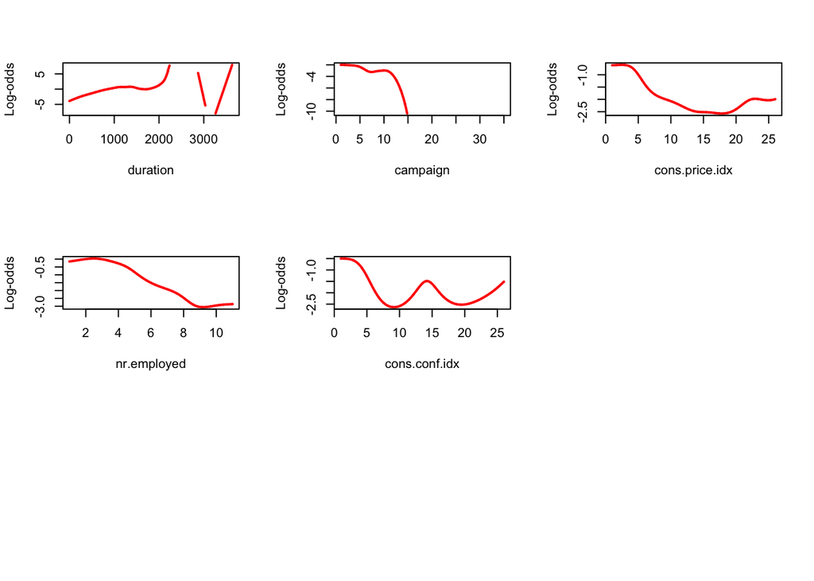

```r
par(mfrow=c(3,3))
for (fact in c("duration", "campaign", "cons.price.idx", "nr.employed", "cons.conf.idx")) {
  lw <- ksmooth(data[[fact]], 1 * (data$y == "yes"), kernel = "normal", bandwidth=sd(data[[fact]]))
  lsm <- log(lw$y / (1-lw$y))
  plot(lw$x, lsm, type="l", xlab=fact, ylab ="Log-odds",col="red", lwd=2)
}
```

По некоторым признакам логит существенно нелинеен. Попробуем подобрать дробные полиномы для непрерывных признаков:

```r
library(mfp)
mfp(y ~ contact + month + poutcome + fp(duration) + fp(campaign) + fp(cons.price.idx) + fp(nr.employed) + fp(cons.conf.idx), family = binomial, data=data)
```

```
## Call:
## mfp(formula = y ~ contact + month + poutcome + fp(duration) +
##     fp(campaign) + fp(cons.price.idx) + fp(nr.employed) + fp(cons.conf.idx),
##     data = data, family = binomial)
##
##
## Deviance table:
##           Resid. Dev
## Null model    2614.84
## Linear model  1496.878
## Final model   1412.842
##
## Fractional polynomials:
##                  df.initial select alpha df.final power1 power2
## duration                  4      1  0.05        4      1      1
## nr.employed               4      1  0.05        1      1      .
## month1                    1      1  0.05        1      1      .
## month2                    1      1  0.05        1      1      .
## month3                    1      1  0.05        1      1      .
## month4                    1      1  0.05        1      1      .
## month5                    1      1  0.05        1      1      .
## month6                    1      1  0.05        1      1      .
## month7                    1      1  0.05        1      1      .
## month8                    1      1  0.05        1      1      .
## month9                    1      1  0.05        1      1      .
## poutcomefailure           1      1  0.05        1      1      .
## poutcomesuccess           1      1  0.05        1      1      .
## contacttelephone          1      1  0.05        1      1      .
## cons.price.idx            4      1  0.05        1      1      .
## campaign                  4      1  0.05        1      1      .
## cons.conf.idx             4      1  0.05        1      1      .
##
##
## Transformations of covariates:
##                                                                                formula
## contact                                                                        contact
## month                                                                            month
## poutcome                                                                      poutcome
## duration       I(((duration+1)/100)^1)+I(((duration+1)/100)^1*log(((duration+1)/100)))
## campaign                                                                 I(campaign^1)
```

[output cut: 11 more lines]

```
##           -3.80387            -0.39590            -0.13010
##           month3.1            month4.1            month5.1
##           -0.09208             0.10071             1.09604
##           month6.1            month7.1            month8.1
##            1.82914            -0.94093            -0.63522
##           month9.1   poutcomefailure.1   poutcomesuccess.1
##            0.01848            -0.29794             1.62625
## contacttelephone.1    cons.price.idx.1          campaign.1
##           -0.67305            -0.47257            -0.08820
##    cons.conf.idx.1
##           -0.32226
##
## Degrees of Freedom: 3809 Total (i.e. Null);  3791 Residual
## Null Deviance:       2615
## Residual Deviance: 1413  AIC: 1451
```

Добавим межфакторные взаимодейсвия

```r
add1(m3, scope= ~ .^2, test="LRT")
```

```
## Single term additions
##
## Model:
## y ~ contact + month + duration + campaign + poutcome + cons.price.idx +
##     nr.employed + cons.conf.idx
##                              Df Deviance    AIC    LRT  Pr(>Chi)
## <none>                            1496.9 1532.9
## contact:month                 9   1495.5 1549.5  1.409 0.9977675
## contact:duration              1   1495.7 1533.7  1.145 0.2845883
## contact:campaign              1   1496.5 1534.5  0.407 0.5233393
## contact:poutcome              2   1493.7 1533.7  3.219 0.1999989
## contact:cons.price.idx        1   1496.9 1534.9  0.014 0.9052575
## contact:nr.employed           1   1491.9 1529.9  5.020 0.0250557 *
## contact:cons.conf.idx         1   1496.1 1534.1  0.821 0.3648765
## month:duration                9   1427.8 1481.8 69.034 2.354e-11 ***
## month:campaign                9   1484.7 1538.7 12.196 0.2024659
## month:poutcome               18   1466.7 1538.7 30.162 0.0358986 *
## month:cons.price.idx          9   1483.9 1537.9 12.973 0.1638359
## month:nr.employed             9   1469.2 1523.2 27.687 0.0010756 **
## month:cons.conf.idx           9   1482.7 1536.7 14.184 0.1159353
## duration:campaign             1   1496.6 1534.6  0.311 0.5772623
## duration:poutcome             2   1495.4 1535.4  1.442 0.4861614
## duration:cons.price.idx       1   1482.5 1520.5 14.380 0.0001494 ***
## duration:nr.employed          1   1493.3 1531.3  3.560 0.0591766 .
## duration:cons.conf.idx        1   1489.2 1527.2  7.717 0.0054697 **
## campaign:poutcome             2   1495.2 1535.2  1.695 0.4283778
## campaign:cons.price.idx       1   1495.7 1533.7  1.200 0.2732274
## campaign:nr.employed          1   1496.0 1534.0  0.931 0.3345026
## campaign:cons.conf.idx        1   1496.8 1534.8  0.063 0.8016549
## poutcome:cons.price.idx       2   1494.4 1534.4  2.469 0.2909141
## poutcome:nr.employed          2   1495.0 1535.0  1.886 0.3894152
## poutcome:cons.conf.idx        2   1495.9 1535.9  0.969 0.6158537
## cons.price.idx:nr.employed    1   1496.1 1534.1  0.820 0.3650831
## cons.price.idx:cons.conf.idx  1   1496.8 1534.8  0.058 0.8103550
## nr.employed:cons.conf.idx     1   1496.5 1534.5  0.366 0.5450471
## ---
## Signif. codes:  0 '***' 0.001 '**' 0.01 '*' 0.05 '.' 0.1 ' ' 1
```

Добавим duration:cons.price.idx + month:duration

```r
m4 <- glm(y ~ contact + month + duration + campaign + poutcome + cons.price.idx + nr.employed + cons.conf.idx + duration:cons.price.idx + month:duration,
          family=binomial(),
          data=data)
summary(m4)
```

```
##
## Call:
## glm(formula = y ~ contact + month + duration + campaign + poutcome +
##     cons.price.idx + nr.employed + cons.conf.idx + duration:cons.price.idx +
##     month:duration, family = binomial(), data = data)
##
## Deviance Residuals:
##     Min       1Q   Median       3Q      Max
## -3.3361  -0.2699  -0.1548  -0.0926   2.9880
##
## Coefficients:
##                           Estimate Std. Error z value Pr(>|z|)
## (Intercept)              1.107e+00  3.810e-01   2.906 0.003660 **
## contacttelephone        -8.946e-01  2.708e-01  -3.303 0.000957 ***
## month1                  -2.981e-01  4.103e-01  -0.727 0.467452
## month2                  -7.301e-01  3.333e-01  -2.190 0.028507 *
## month3                   6.829e-01  8.578e-01   0.796 0.425996
## month4                  -5.702e-01  4.041e-01  -1.411 0.158309
## month5                   1.722e-01  3.740e-01   0.460 0.645171
## month6                   1.973e+00  5.141e-01   3.838 0.000124 ***
## month7                  -1.594e+00  3.208e-01  -4.969 6.74e-07 ***
## month8                  -5.582e-01  3.371e-01  -1.656 0.097744 .
## month9                   6.305e-01  3.587e-01   1.758 0.078756 .
## duration                 3.139e-03  7.349e-04   4.272 1.94e-05 ***
## campaign                -1.065e-01  4.856e-02  -2.192 0.028355 *
## poutcomefailure         -3.240e-01  2.035e-01  -1.592 0.111295
## poutcomesuccess          1.497e+00  2.565e-01   5.838 5.27e-09 ***
## cons.price.idx          -6.662e-02  2.336e-02  -2.853 0.004337 **
## nr.employed             -3.970e-01  3.449e-02 -11.510  < 2e-16 ***
## cons.conf.idx           -1.442e-02  1.683e-02  -0.857 0.391332
## duration:cons.price.idx  6.306e-05  5.341e-05   1.181 0.237754
## month1:duration          3.400e-04  8.164e-04   0.417 0.677035
## month2:duration          2.373e-03  7.521e-04   3.155 0.001604 **
## month3:duration         -1.282e-03  1.990e-03  -0.644 0.519466
## month4:duration          1.936e-03  7.451e-04   2.599 0.009356 **
## month5:duration          2.833e-03  9.056e-04   3.128 0.001759 **
## month6:duration         -1.999e-03  1.484e-03  -1.347 0.178023
## month7:duration          2.216e-03  5.805e-04   3.817 0.000135 ***
## month8:duration          2.969e-04  6.546e-04   0.454 0.650159
## month9:duration         -3.239e-03  7.412e-04  -4.370 1.24e-05 ***
## ---
## Signif. codes:  0 '***' 0.001 '**' 0.01 '*' 0.05 '.' 0.1 ' ' 1
##
## (Dispersion parameter for binomial family taken to be 1)
##
##     Null deviance: 2614.8  on 3809  degrees of freedom
## Residual deviance: 1426.5  on 3782  degrees of freedom
## AIC: 1482.5
##
## Number of Fisher Scoring iterations: 7
```

```r
lrtest(m3, m4)
```

```
## Likelihood ratio test
##
## Model 1: y ~ contact + month + duration + campaign + poutcome + cons.price.idx +
##     nr.employed + cons.conf.idx
## Model 2: y ~ contact + month + duration + campaign + poutcome + cons.price.idx +
##     nr.employed + cons.conf.idx + duration:cons.price.idx + month:duration
##   #Df  LogLik Df  Chisq Pr(>Chisq)
## 1  18 -748.44
## 2  28 -713.23 10 70.421  3.676e-11 ***
## ---
## Signif. codes:  0 '***' 0.001 '**' 0.01 '*' 0.05 '.' 0.1 ' ' 1
```

По критерию отношения правдоподобия получается улучшение, добавим межфакторные взаимодействия.

## Модель 5

Попробуем удалить влиятельные наблюдения:

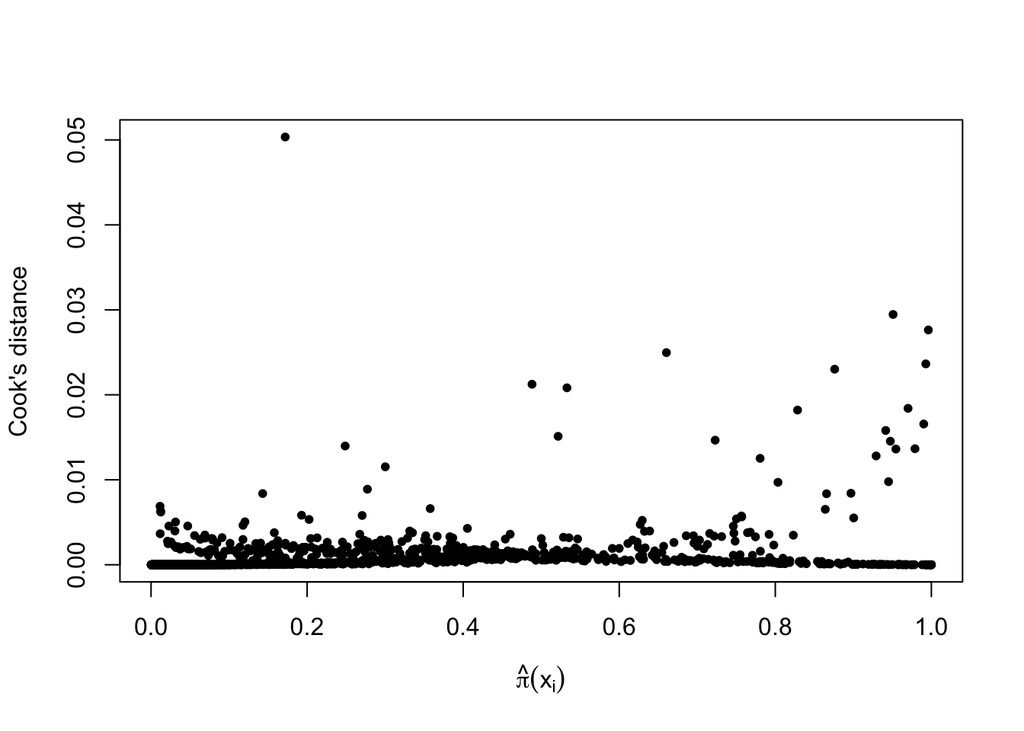

```r
phat <- predict(m4, type="response")

par(mfrow=c(1,1))
plot(phat, cooks.distance(m4), pch=20, xlab=expression(hat(pi)(x[i])), ylab="Cook's distance")
lines(c(0,1), c(0.15,0.15), col="red", lwd=2)
```

```r
data2 <- data[cooks.distance(m3)<0.025,]
m5  <- glm(y ~ contact + month + duration + campaign + poutcome + cons.price.idx + nr.employed + cons.conf.idx + duration:cons.price.idx + month:duration, family=binomial(), data=data2)
summary(m5)
```

```
##
## Call:
## glm(formula = y ~ contact + month + duration + campaign + poutcome +
##     cons.price.idx + nr.employed + cons.conf.idx + duration:cons.price.idx +
##     month:duration, family = binomial(), data = data2)
##
## Deviance Residuals:
##     Min       1Q   Median       3Q      Max
## -3.3358  -0.2705  -0.1549  -0.0925   3.0306
##
## Coefficients:
##                           Estimate Std. Error z value Pr(>|z|)
## (Intercept)              1.115e+00  3.816e-01   2.921 0.003493 **
## contacttelephone        -8.818e-01  2.713e-01  -3.250 0.001153 **
## month1                  -2.834e-01  4.109e-01  -0.690 0.490339
## month2                  -7.110e-01  3.342e-01  -2.127 0.033401 *
## month3                   6.882e-01  8.573e-01   0.803 0.422095
## month4                  -5.309e-01  4.068e-01  -1.305 0.191875
## month5                   2.121e-01  3.772e-01   0.562 0.573908
## month6                   1.981e+00  5.139e-01   3.854 0.000116 ***
## month7                  -1.570e+00  3.219e-01  -4.878 1.07e-06 ***
## month8                  -5.379e-01  3.380e-01  -1.591 0.111553
## month9                   4.459e-01  4.313e-01   1.034 0.301183
## duration                 3.121e-03  7.424e-04   4.205 2.62e-05 ***
## campaign                -1.071e-01  4.860e-02  -2.204 0.027496 *
## poutcomefailure         -3.148e-01  2.036e-01  -1.547 0.121983
## poutcomesuccess          1.498e+00  2.565e-01   5.840 5.23e-09 ***
## cons.price.idx          -7.003e-02  2.383e-02  -2.938 0.003302 **
## nr.employed             -3.965e-01  3.454e-02 -11.478  < 2e-16 ***
## cons.conf.idx           -1.387e-02  1.690e-02  -0.821 0.411688
## duration:cons.price.idx  7.157e-05  5.495e-05   1.302 0.192769
## month1:duration          2.615e-04  8.229e-04   0.318 0.750631
## month2:duration          2.293e-03  7.601e-04   3.016 0.002560 **
## month3:duration         -1.318e-03  1.991e-03  -0.662 0.507788
## month4:duration          1.801e-03  7.647e-04   2.355 0.018498 *
## month5:duration          2.666e-03  9.295e-04   2.868 0.004131 **
## month6:duration         -2.053e-03  1.486e-03  -1.382 0.166972
## month7:duration          2.108e-03  5.953e-04   3.541 0.000398 ***
## month8:duration          2.124e-04  6.632e-04   0.320 0.748737
## month9:duration         -2.461e-03  1.250e-03  -1.969 0.049001 *
## ---
## Signif. codes:  0 '***' 0.001 '**' 0.01 '*' 0.05 '.' 0.1 ' ' 1
##
## (Dispersion parameter for binomial family taken to be 1)
##
##     Null deviance: 2614.6  on 3808  degrees of freedom
## Residual deviance: 1425.6  on 3781  degrees of freedom
## AIC: 1481.6
##
## Number of Fisher Scoring iterations: 7
```

Сравнить полученные коэффициенты с коэффициентами модели, настроенной по полным данным:

```r
res <- cbind(coefficients(m4), coefficients(m5))
colnames(res) <- c("All data", "Filtered data")
res
```

```
##                              All data Filtered data
## (Intercept)              1.107256e+00  1.114583e+00
## contacttelephone        -8.945553e-01 -8.817757e-01
## month1                  -2.981372e-01 -2.834347e-01
## month2                  -7.300765e-01 -7.109550e-01
## month3                   6.828549e-01  6.882457e-01
## month4                  -5.701659e-01 -5.309455e-01
## month5                   1.722074e-01  2.120791e-01
## month6                   1.973042e+00  1.980604e+00
## month7                  -1.593947e+00 -1.570461e+00
## month8                  -5.582156e-01 -5.378645e-01
## month9                   6.304987e-01  4.459148e-01
## duration                 3.139444e-03  3.121417e-03
## campaign                -1.064658e-01 -1.071446e-01
## poutcomefailure         -3.240211e-01 -3.148496e-01
## poutcomesuccess          1.497459e+00  1.498061e+00
## cons.price.idx          -6.662157e-02 -7.002853e-02
## nr.employed             -3.969708e-01 -3.964724e-01
## cons.conf.idx           -1.442342e-02 -1.387445e-02
## duration:cons.price.idx  6.306063e-05  7.157455e-05
## month1:duration          3.400411e-04  2.615261e-04
## month2:duration          2.373091e-03  2.292640e-03
## month3:duration         -1.282148e-03 -1.318456e-03
## month4:duration          1.936426e-03  1.801234e-03
## month5:duration          2.832782e-03  2.665744e-03
## month6:duration         -1.998920e-03 -2.053127e-03
## month7:duration          2.215587e-03  2.108236e-03
## month8:duration          2.968711e-04  2.124186e-04
## month9:duration         -3.239232e-03 -2.461132e-03
```

#### Итог

Посмотрим на качество классификации:

```r
library(AUC)
```

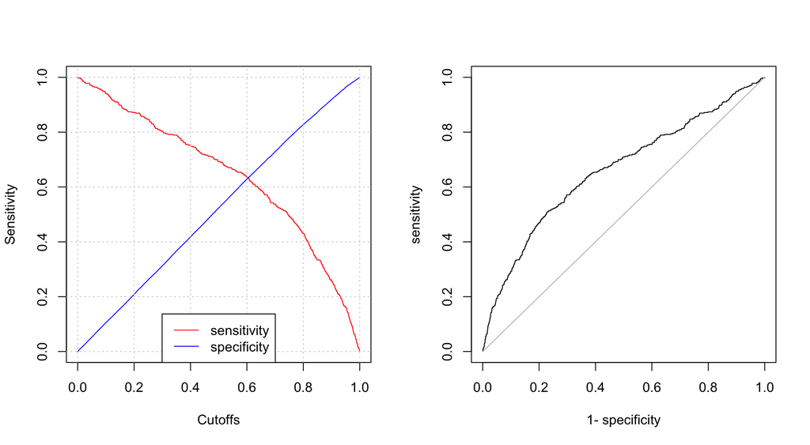

```r
par(mfrow=c(1,2))
phat <- predict(m5, type="response")

sens <- sensitivity(phat, factor(1 * (data$y == "yes")))
plot(sens, col="red")
spec <- specificity(phat, factor(1 * (data$y == "yes")))
lines(spec$cutoffs, spec$measure, col="blue", ylab="")
grid()
legend("bottom", c("sensitivity", "specificity"), lty=c(1,1), col=c("red", "blue"))

r <- roc(phat, factor(1 * (data$y == "yes")))
plot(r)
```

```r
auc(r)
```

```
## [1] 0.6613655
```

```r
lrtest(m3,m0)$"Pr(>Chisq)"[2]
```

```
## [1] 5.033309e-227
```

Порог 0.6. площадь под ROC-кривой составляет 0.6613655. Значимость модели по критерию отношения правдоподобия равна 5.033308510^{-227}.

Приросты отношений шансов на патологию для каждого признака и доверительные интервалы для них:

```r
summary(m5)
```

```
##
## Call:
## glm(formula = y ~ contact + month + duration + campaign + poutcome +
##     cons.price.idx + nr.employed + cons.conf.idx + duration:cons.price.idx +
##     month:duration, family = binomial(), data = data2)
##
## Deviance Residuals:
##     Min       1Q   Median       3Q      Max
## -3.3358  -0.2705  -0.1549  -0.0925   3.0306
##
## Coefficients:
##                           Estimate Std. Error z value Pr(>|z|)
## (Intercept)              1.115e+00  3.816e-01   2.921 0.003493 **
## contacttelephone        -8.818e-01  2.713e-01  -3.250 0.001153 **
## month1                  -2.834e-01  4.109e-01  -0.690 0.490339
## month2                  -7.110e-01  3.342e-01  -2.127 0.033401 *
## month3                   6.882e-01  8.573e-01   0.803 0.422095
## month4                  -5.309e-01  4.068e-01  -1.305 0.191875
## month5                   2.121e-01  3.772e-01   0.562 0.573908
## month6                   1.981e+00  5.139e-01   3.854 0.000116 ***
## month7                  -1.570e+00  3.219e-01  -4.878 1.07e-06 ***
## month8                  -5.379e-01  3.380e-01  -1.591 0.111553
## month9                   4.459e-01  4.313e-01   1.034 0.301183
## duration                 3.121e-03  7.424e-04   4.205 2.62e-05 ***
## campaign                -1.071e-01  4.860e-02  -2.204 0.027496 *
## poutcomefailure         -3.148e-01  2.036e-01  -1.547 0.121983
## poutcomesuccess          1.498e+00  2.565e-01   5.840 5.23e-09 ***
## cons.price.idx          -7.003e-02  2.383e-02  -2.938 0.003302 **
## nr.employed             -3.965e-01  3.454e-02 -11.478  < 2e-16 ***
## cons.conf.idx           -1.387e-02  1.690e-02  -0.821 0.411688
## duration:cons.price.idx  7.157e-05  5.495e-05   1.302 0.192769
## month1:duration          2.615e-04  8.229e-04   0.318 0.750631
## month2:duration          2.293e-03  7.601e-04   3.016 0.002560 **
## month3:duration         -1.318e-03  1.991e-03  -0.662 0.507788
## month4:duration          1.801e-03  7.647e-04   2.355 0.018498 *
## month5:duration          2.666e-03  9.295e-04   2.868 0.004131 **
## month6:duration         -2.053e-03  1.486e-03  -1.382 0.166972
## month7:duration          2.108e-03  5.953e-04   3.541 0.000398 ***
## month8:duration          2.124e-04  6.632e-04   0.320 0.748737
## month9:duration         -2.461e-03  1.250e-03  -1.969 0.049001 *
## ---
## Signif. codes:  0 '***' 0.001 '**' 0.01 '*' 0.05 '.' 0.1 ' ' 1
##
## (Dispersion parameter for binomial family taken to be 1)
##
##     Null deviance: 2614.6  on 3808  degrees of freedom
## Residual deviance: 1425.6  on 3781  degrees of freedom
## AIC: 1481.6
##
## Number of Fisher Scoring iterations: 7
```

```r
exp(coefficients(m5))[-1]
```

```
##        contacttelephone                  month1                  month2
##               0.4140470               0.7531923               0.4911749
##                  month3                  month4                  month5
##               1.9902209               0.5880487               1.2362457
##                  month6                  month7                  month8
##               7.2471185               0.2079494               0.5839940
##                  month9                duration                campaign
##               1.5619184               1.0031263               0.8983957
##         poutcomefailure         poutcomesuccess          cons.price.idx
##               0.7298986               4.4730071               0.9323672
##             nr.employed           cons.conf.idx duration:cons.price.idx
##               0.6726888               0.9862214               1.0000716
##         month1:duration         month2:duration         month3:duration
##               1.0002616               1.0022953               0.9986824
##         month4:duration         month5:duration         month6:duration
##               1.0018029               1.0026693               0.9979490
##         month7:duration         month8:duration         month9:duration
##               1.0021105               1.0002124               0.9975419
```

```r
exp(confint(m5))[-1,]
```

```
##                             2.5 %     97.5 %
## contacttelephone        0.2393976  0.6947094
## month1                  0.3220855  1.6294048
## month2                  0.2511479  0.9336060
## month3                  0.3374432 10.1373347
## month4                  0.2571671  1.2741856
## month5                  0.5780445  2.5468472
## month6                  2.4467387 19.3020001
## month7                  0.1087002  0.3852688
## month8                  0.2937470  1.1097146
## month9                  0.6422853  3.5681756
## duration                1.0016842  1.0046221
## campaign                0.8136347  0.9839893
## poutcomefailure         0.4865261  1.0817693
## poutcomesuccess         2.7153684  7.4330423
## cons.price.idx          0.8896292  0.9769248
## nr.employed             0.6280425  0.7192874
## cons.conf.idx           0.9539475  1.0193959
## duration:cons.price.idx 0.9999634  1.0001796
## month1:duration         0.9987156  1.0019726
## month2:duration         1.0008353  1.0038314
## month3:duration         0.9948978  1.0029912
## month4:duration         1.0003262  1.0033393
## month5:duration         1.0008723  1.0045325
## month6:duration         0.9953424  1.0016625
## month7:duration         1.0009503  1.0032985
## month8:duration         0.9989349  1.0015444
## month9:duration         0.9951756  1.0003730
```

```r
levels(data$month)
```

```
##  [1] "apr" "aug" "dec" "jul" "jun" "mar" "may" "nov" "oct" "sep"
```

```r
round(1 / exp(coefficients(m5))["month2"], 2)
```

```
## month2
##   2.04
```

```r
ftable(data$month, data$y)
```

```
##        no  yes
##
## apr   165   31
## aug   532   58
## dec    10    9
## jul   599   56
## jun   424   61
## mar    19   24
## may  1191   84
## nov   383   43
## oct    39   25
## sep    35   22
```

Расшифровки обозначений для признаков в финальной модели:

contact: contact communication type (categorical: “cellular”,“telephone”) month: last contact month of year (categorical: “jan”, “feb”, “mar”, …, “nov”, “dec”) duration: last contact duration, in seconds (numeric). campaign: number of contacts performed during this campaign and for this client (numeric, includes last contact) poutcome: outcome of the previous marketing campaign (categorical: “failure”,“nonexistent”,“success”) cons.price.idx: consumer price index - monthly indicator (numeric) cons.conf.idx: consumer confidence index - monthly indicator (numeric) nr.employed: number of employees - quarterly indicator (numeric)